# Introduction to Model Interpretability

In the previous sections of this tutorial series, you have learned how to train models with DeepChem on a variety of applications. But we have not yet really studied the question of model explainability.

Often times when modeling we are asked the question -- How does the model work? Why should we trust this model? My response as a data scientist is usually, "because we have rigorously proved model performance on a holdout testset with splits that are realistic to the real world". Oftentimes that is not enough to convince domain experts.

[LIME](https://homes.cs.washington.edu/~marcotcr/blog/lime/) is a tool which can help with this problem. It uses local perturbations of feature space to determine feature importance. In this tutorial, you'll learn how to use LIME alongside DeepChem to interpret what it is our models are learning.

[figure not shown]

So if this tool can work in human understandable ways for images can it work on molecules? In this tutorial you will learn how to use LIME for model interpretability for any of our fixed-length featurization models.

## Colab

```python
!pip install --pre deepchem
import deepchem
deepchem.__version__
```

## Making of the Model

Let's begin by loading the Tox21 dataset with ECFP featurization. Recall how this featurization works. It identifies small fragments within each molecule, then sets elements of the output vector to 1 to indicate which fragments are present in a particular molecule.

```python
import deepchem as dc
n_features = 1024
tasks, datasets, transformers = dc.molnet.load_tox21(featurization='ecfp')
train_dataset, valid_dataset, test_dataset = datasets
```

Let's now train a model to work on this dataset. As in previous tutorials, we'll use a MultitaskClassifier, which is a simple stack of dense layers.

```python
n_tasks = len(tasks)
n_features = train_dataset.get_data_shape()[0]
model = dc.models.MultitaskClassifier(n_tasks, n_features)
model.fit(train_dataset, nb_epoch=50)
```

```
0.1333492088317871
```

Let's evaluate this model on the training and validation sets to get some basic understanding of its accuracy. We'll use the ROC-AUC as our metric of choice.

```python
import numpy as np
metric = dc.metrics.Metric(dc.metrics.roc_auc_score, np.mean)
print("Train scores")
print(model.evaluate(train_dataset, [metric], transformers))
print("Validation scores")
print(model.evaluate(valid_dataset, [metric], transformers))
```

```
Train scores
{'mean-roc_auc_score': 0.9911206354520975}
Validation scores
{'mean-roc_auc_score': 0.699686047497269}
```

## Using LIME

The model seems to do a reasonable job of predicting which molecules are toxic, but how does it work? When it predicts that a particular molecule is toxic or non-toxic, what aspects of the molecule led to that prediction? This is the essence of *explainability*: learning why an input led to a certain prediction.

LIME is a tool for addressing this problem. The name is short for "Local Interpretable Model-Agnostic Explanations". It can work on any problem with a fixed size input vector. It works by computing probability distributions for the individual features and the covariance between the features. This allows it to construct a local linear model in the neighborhood of a sample, describing what local perturbations of the input would have the biggest effect on the output. That is, what fragments added to or removed from the molecule would be most likely to change the prediction between toxic and non-toxic?

First we need to install lime. Luckily, lime is conveniently available on `pip`, so you can install it from within this Jupyter notebook.

```python
!pip install lime
```

Now that we have lime installed, we want to create an `Explainer` object for `lime`. This object will take in the training dataset and names for the features. We're using circular fingerprints as our features. We don't have natural names for our features, so we just number them numerically. On the other hand, we do have natural names for our labels. Recall that Tox21 is for toxicity assays; so let's call 0 as 'not toxic' and 1 as 'toxic'.

```python
from lime import lime_tabular
feature_names = ["fp_%s"  % x for x in range(1024)]
explainer = lime_tabular.LimeTabularExplainer(train_dataset.X,
                                              feature_names=feature_names,
                                              categorical_features=feature_names,
                                              class_names=['not toxic', 'toxic'],
                                              discretize_continuous=True)
```

We are going to attempt to explain why the model predicts a molecule to be toxic for NR-AR. The specific assay details can be found [here](https://pubchem.ncbi.nlm.nih.gov/bioassay/743040).

```python
# We need a function which takes a 2d numpy array (samples, features) and returns predictions (samples,)
def eval_model(my_model):
    def eval_closure(x):
        ds = dc.data.NumpyDataset(x, n_tasks=12)
        # The 0th task is NR-AR
        predictions = my_model.predict(ds)[:,0]
        return predictions
    return eval_closure

model_fn = eval_model(model)
```

Let's now attempt to use this evaluation function on a specific molecule. Let's pick the first molecule in the test set that is correctly predicted to be toxic (that is, the molecule is toxic, and the model correctly predicts it to be toxic).

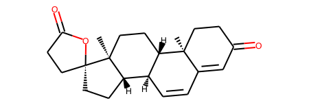

```python
from rdkit import Chem
active_id = np.where((test_dataset.y[:,0] == 1) * (model.predict(test_dataset)[:,0,1] > 0.8))[0][0]
Chem.MolFromSmiles(test_dataset.ids[active_id])
```

Now that we have a trained model and a molecule, let's ask the `Explainer` to figure out why the molecule was predicted to be toxic. We ask it for the 100 features (that is, elements in the fingerprint, each corresponding to one or more fragments) the prediction is most sensitive to.

```python
exp = explainer.explain_instance(test_dataset.X[active_id], model_fn, num_features=100, top_labels=1)
```

The returned value is an `Explanation` object. It has methods you can call to retrieve the results in various forms. A convenient form for working interactively is `show_in_notebook()`, providing a graphical representation.

```python
exp.show_in_notebook(show_table=True, show_all=False)
```

[output not shown]

Most of the fragments are not present. It's telling us about fragments that, *if* they were present, would shift the prediction. We aren't very interested in those. We want to know about the fragments that *are* present in the molecule that are contributing to the prediction. Let's try to put these results into a more useful form.

To start, indices within the fingerprint aren't very informative. Let's write a function to reverse the featurization, mapping from indices back to the fragments that activated them.

```python
def fp_mol(mol, fp_length=1024):
    """
    returns: dict of <int:list of string>
        dictionary mapping fingerprint index
        to list of SMILES strings that activated that fingerprint
    """
    d = {}
    feat = dc.feat.CircularFingerprint(sparse=True, smiles=True, size=1024)
    retval = feat._featurize(mol)
    for k, v in retval.items():
        index = k % fp_length
        if index not in d:
            d[index] = set()
        d[index].add(v['smiles'])
    return d

# What fragments activated what fingerprints in our active molecule?
my_fragments = fp_mol(Chem.MolFromSmiles(test_dataset.ids[active_id]))
```

Now we want to query the `Explanation` to see which of those fragments contributed to the prediction. We can use the `as_map()` method to get the information in a form more suitable for processing.

```python
print(exp.as_map())
```

[output not shown]

The keys in this map are the labels, of which we only have one. The value is a list of tuples, each of the form (fingerprint_index, weight). Let's convert it to a dict mapping indices to weights.

```python
fragment_weight = dict(exp.as_map()[1])
```

We know which fragments are present in our molecule of interest (`my_fragments`), and we know which fragments contributed to the prediction (`fragment_weights`). Let's loop over them and print them out.

```python
for index in my_fragments:
    if index in fragment_weight:
        print(index, my_fragments[index], fragment_weight[index])
```

```
555 {'C[C@](C)(C)CCC'} 0.09105473925802852
84 {'C=CC'} 0.123345144700625
519 {'C[C@@H](C)C'} 0.09315063287813262
274 {'C[C@@H](C)C(C=C)[C@@H](C)C'} -0.07528620889379731
529 {'CCC[C@H](C)C'} 0.12194683881762106
```

# Congratulations! Time to join the Community!

Congratulations on completing this tutorial notebook! If you enjoyed working through the tutorial, and want to continue working with DeepChem, we encourage you to finish the rest of the tutorials in this series. You can also help the DeepChem community in the following ways:

## Star DeepChem on [GitHub](https://github.com/deepchem/deepchem)

This helps build awareness of the DeepChem project and the tools for open source drug discovery that we're trying to build.

## Join the DeepChem Gitter

The DeepChem [Gitter](https://gitter.im/deepchem/Lobby) hosts a number of scientists, developers, and enthusiasts interested in deep learning for the life sciences. Join the conversation!